# 260-2017-10-06-development

2017-10-05 13:25:48

## Today's Topics

- Wrap-up on brain evolution
- How the human brain develops

## Selection pressures

- Natural and sexual selection for
  - Traits that improve reproductive success
- Physical AND psychological traits
  - Hardware and software

## Samsung Galaxy S8

[figure not shown]

## Apple iPhone X

[figure not shown]

## Virtues of big phones/brains

- More storage
- More processing capacity
- Better sensors
- Better output
- More, better apps
- Do more, faster

## Costs of big brains

- Long time to build
- Lots of energy to nourish/maintain
- Long time to program/train/educate
- Head/neck must be strong enough to carry
- How to connect brain/body parts widely, but process info quickly

## Does size matter? Maybe not so much.

[figure not shown]

## A new view (Herculano-Houzel 2016)

- **Number** of neurons in *cerebral cortex* makes humans "special"

| Species | # cortical neurons | cortical mass (g) |
| --- | --- | --- |
| Human | 16 B | 1233 |
| Chimpanzee | 6 B | 286 |
| Elephant | 5.6 B | 2800 |
| Baboon | 2.9 B | 120.2 |

## A new view (Herculano-Houzel 2016)

| Species | # cortical neurons | cortical mass (g) |
| --- | --- | --- |
| Giraffe | 1.7 B | 398.8 |
| Rhesus | 1.7 B | 69.8 |
| Pig | 303 M | 42.2 |
| Rabbit | 71 M | 4.4 |

## But humans follow scaling rules typical of other animals

[figure not shown]

[(Herculano-Houzel 2012)](http://doi.org/10.1073/pnas.1201895109)

## # of cortical (or its equivalent) neurons predicts "cognition"?

[figure not shown]

[(Herculano-Houzel 2017)](http://doi.org/10.1016/j.cobeha.2017.02.004)

## How did human brain get this way?

- Build upon mammalian/primate norms
  - Add neurons to cerebral cortex
- More efficient energy intake
  - calories/hr foraging vs.
  - cooking?
- Prolonged (in time) pattern of development
- Specialized pattern of development
  - Significant time post-natal/pre-reproductive (childhood)

## Human brain development take homes

- Prenatal
  - Neuro- and gliogenesis
  - Migration
  - Synaptogenesis begins
  - Differentiation
  - Apoptosis
  - Myelination begins
  - Infant gene expression ≠ Adult

## Human brain development take homes

- Postnatal
  - Synaptogenesis
  - Cortical expansion, activity-dependent change
  - Myelination
  - Prolonged period of postnatal/pre-reproductive development, i.e., childhood (Konner 2011)

## Neurulation

[figure not shown]

## Formation of neural tube (neurulation)

- Three embryonic tissue layers: Ectoderm, mesoderm, endoderm
- Ectoderm folds on itself to form neural tube
  - ~20 days post-fertilization
- Neural tube becomes
  - Ventricles (and cerebral aqueduct)
  - Central canal of spinal cord
  - rostral/caudal axis of CNS

## Neurulation

- Failures of neural tube closure
  - Spina bifida
  - Anencephaly

## Spina Bifida

[figure not shown]

## Neurogenesis and gliogenesis

- Stem cells along ventricles
- Symmetric cell division
  - Daughter cells can also divide, increases # of proliferative cells
- Asymmetric cell division
  - Daughter cells post-mitotic (don't divide)

## Radial glia

[figure not shown]

## Cell migration

[figure not shown]

## Radial unit hypothesis

[figure not shown]

[(Rakic 2009)](http://dx.doi.org/10.1038/nrn2719)

## Radial unit hypothesis

- "Units" along rostral/caudal and superior inferior axis determine "fate" of associated CNS region

## Migration

[video not shown]

## Migration

[video not shown]

## Glial migration

[figure not shown]

http://physrev.physiology.org/content/81/2/871

## Axon growth cone

[video not shown]

## Axons follow

- Chemoattractants
  - e.g., Nerve Growth Factor (NGF)
- Chemorepellents
- Receptors in growth cone detect chemical gradients

## Differentiation

- Neuron vs. glial cell
- Cell type
- NTs released
- Where to connect

## Differential gene expression by cortical area

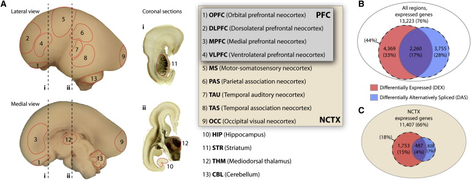

[(Johnson et al. 2009)](http://dx.doi.org/10.1016/j.neuron.2009.03.027)

## Prefrontal vs. Other Ctx

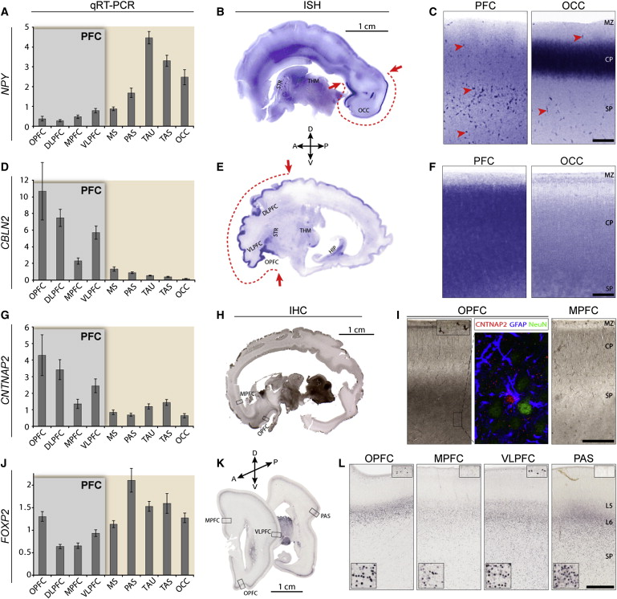

[(Johnson et al. 2009)](http://dx.doi.org/10.1016/j.neuron.2009.03.027)

## Synaptogenesis

[figure not shown]

## Postnatal patterns of synaptogenesis

[figure not shown]

## Proliferation, pruning

- Early proliferation
- Later pruning
- Rates, peaks differ by area

## Apoptosis

- "Programmed" cell death
- 20-80%, varies by area
- Spinal cord >> cortex

## Apoptosis and cortical expansion

[figure not shown]

[(Rakic 2009)](http://dx.doi.org/10.1038/nrn2719)

## Synaptic rearrangement

[figure not shown]

## Myelination

[figure not shown]

## Myelination

- Neonatal brain largely unmyelinated
- Gradual myelination, peaks in mid-20s
- Spinal cord before brain
- Sensory before motor, except in dorsal/ventral roots of PNS

## Diffusion Tensor Imaging (DTI)

- Structural MRI measure
- Diffusion of water molecules
- Diffusion in a specific direction (aniosotropy) -> white matter integrity

## DTI

[video not shown]

## Myelination across human development

[figure not shown]

(Hagmann et al. 2010)

## Myelination changes "network" properties

[figure not shown]

(Hagmann et al. 2010)

## Synaptic rearrangment, myelination change cortical thickness

- [[Gogtay2004-bq]](http://doi.org/10.1073/pnas.0402680101)
- Thickness of cerebral cortex *declines*
  - Synaptic pruning?
- Areas differ

## [[Gogtay2004-bq]](http://doi.org/10.1073/pnas.0402680101)

[video not shown]

## Human brain development take homes

- Prenatal
  - Neuro- and gliogenesis
  - Migration
  - Synaptogenesis begins
  - Differentiation
  - Apoptosis
  - Myelination begins
  - Infant gene expression ≠ Adult

## Human brain development take homes

- Postnatal
  - Synaptogenesis
  - Cortical expansion, activity-dependent change
  - Myelination
  - Prolonged period of postnatal/pre-reproductive development

## Next time…

- Brain development beyond childhood

## References

Hagmann, P., O. Sporns, N. Madan, L. Cammoun, R. Pienaar, V. J. Wedeen, R. Meuli, J.-P. Thiran, and P. E. Grant. 2010. “White Matter Maturation Reshapes Structural Connectivity in the Late Developing Human Brain.” *Proceedings of the National Academy of Sciences* 107 (44): 19067–72. doi:10.1073/pnas.1009073107.

Herculano-Houzel, Suzana. 2012. “The Remarkable, yet Not Extraordinary, Human Brain as a Scaled-up Primate Brain and Its Associated Cost.” *Proc. Natl. Acad. Sci. U. S. A.* 109 Suppl 1 (June). National Acad Sciences: 10661–8. doi:10.1073/pnas.1201895109.

———. 2016. *The Human Advantage: A New Understanding of How Our Brain Became Remarkable*. MIT Press. https://market.android.com/details?id=book-DMqpCwAAQBAJ.

———. 2017. “Numbers of Neurons as Biological Correlates of Cognitive Capability.” *Current Opinion in Behavioral Sciences* 16 (Supplement C): 1–7. doi:10.1016/j.cobeha.2017.02.004.

Johnson, Matthew B, Yuka Imamura Kawasawa, Christopher E Mason, Željka Krsnik, Giovanni Coppola, Darko Bogdanović, Daniel H Geschwind, Shrikant M Mane, Matthew W State, and Nenad Šestan. 2009. “Functional and Evolutionary Insights into Human Brain Development Through Global Transcriptome Analysis.” *Neuron* 62 (4). Elsevier: 494–509.

Konner, Melvin. 2011. *The Evolution of Childhood*. Belknap Press of Harvard University Press. http://www.hup.harvard.edu/catalog.php?isbn=9780674062016.

Rakic, Pasko. 2009. “Evolution of the Neocortex: A Perspective from Developmental Biology.” *Nature Reviews Neuroscience* 10 (10). Nature Publishing Group: 724–35. doi:10.1038/nrn2719.